# Machine Learning Course Project

Biswajit Khandai

December 22, 2018

## Introduction

In this project, we use machine learning on activity tracker data from fitness devices such as Jawbone and Fitbit. The training and the testing data are in separate sets. We learn from the training set and apply the model to the testing set to predict whether the exercises performed by participants used proper form or not.

## Acknowledgement

The data for this project come from this source: http://groupware.les.inf.puc-rio.br/har

Ugulino, W.; Cardador, D.; Vega, K.; Velloso, E.; Milidiu, R.; Fuks, H. Wearable Computing: Accelerometers’ Data Classification of Body Postures and Movements. Proceedings of 21st Brazilian Symposium on Artificial Intelligence. Advances in Artificial Intelligence - SBIA 2012. In: Lecture Notes in Computer Science. , pp. 52-61. Curitiba, PR: Springer Berlin / Heidelberg, 2012. ISBN 978-3-642-34458-9. DOI: 10.1007/978-3-642-34459-6_6.

## Load the data

```r
trng_url = "http://d396qusza40orc.cloudfront.net/predmachlearn/pml-training.csv";
test_url = "http://d396qusza40orc.cloudfront.net/predmachlearn/pml-testing.csv";

training = read.csv(url(trng_url), header=TRUE, na.strings=c("NA","#DIV/0!",""));
testing  = read.csv(url(test_url), header=TRUE, na.strings=c("NA","#DIV/0!",""));
```

## Clean up the data a bit.

```r
trng_cleaned = training[, -c(1:7)];
trng_cleaned = trng_cleaned[sapply(trng_cleaned,
                   function(x) {sum(is.na(x)) < (0.2 * nrow(trng_cleaned))})];
dim(trng_cleaned);
```

```
## [1] 19622    53
```

```r
test_cleaned = testing[, -1];
test_cleaned = test_cleaned[sapply(test_cleaned,
                   function(x) {sum(is.na(x)) < (0.2 * nrow(test_cleaned))})];
```

### Slice the training data into training and validation

Let’s split the cleaned training data into 70% pure training data and 30% validation data. We will use the validation data set to conduct cross validation in future steps.

```r
set.seed (1000) # For reproducibile results
in_train   = createDataPartition (trng_cleaned$classe, p = 0.70, list = FALSE)
train_partition  = trng_cleaned[in_train, ]
valid_partition  = trng_cleaned[-in_train, ]
```

## Train the Model on the training partition

We will use the **Random Forest** algorithm to train the model. Random forest automatically selects the most significant variables. We choose a 5-fold cross validation.

```r
trng_ctrl = trainControl (method = "cv", 5)
mdl_rf    = train (classe ~ ., data = train_partition,
                   method="rf", trControl = trng_ctrl)
mdl_rf
```

```
## Random Forest
##
## 13737 samples
##    52 predictor
##     5 classes: 'A', 'B', 'C', 'D', 'E'
##
## No pre-processing
## Resampling: Cross-Validated (5 fold)
## Summary of sample sizes: 10989, 10990, 10989, 10990, 10990
## Resampling results across tuning parameters:
##
##   mtry  Accuracy   Kappa
##    2    0.9899541  0.9872909
##   27    0.9900268  0.9873834
##   52    0.9863140  0.9826874
##
## Accuracy was used to select the optimal model using the largest value.
## The final value used for the model was mtry = 27.
```

## Estimate the accuracy of the model on the validation partition.

```r
pred_rf = predict (mdl_rf, valid_partition);
confusionMatrix (valid_partition$classe, pred_rf);
```

```
## Confusion Matrix and Statistics
##
##           Reference
## Prediction    A    B    C    D    E
##          A 1671    3    0    0    0
##          B    7 1131    1    0    0
##          C    0   10 1014    2    0
##          D    0    0   20  943    1
##          E    0    0    0    4 1078
##
## Overall Statistics
##
##                Accuracy : 0.9918
##                  95% CI : (0.9892, 0.994)
##     No Information Rate : 0.2851
##     P-Value [Acc > NIR] : < 2.2e-16
##
##                   Kappa : 0.9897
##  Mcnemar's Test P-Value : NA
##
## Statistics by Class:
##
##                      Class: A Class: B Class: C Class: D Class: E
## Sensitivity            0.9958   0.9886   0.9797   0.9937   0.9991
## Specificity            0.9993   0.9983   0.9975   0.9957   0.9992
## Pos Pred Value         0.9982   0.9930   0.9883   0.9782   0.9963
## Neg Pred Value         0.9983   0.9973   0.9957   0.9988   0.9998
## Prevalence             0.2851   0.1944   0.1759   0.1613   0.1833
## Detection Rate         0.2839   0.1922   0.1723   0.1602   0.1832
## Detection Prevalence   0.2845   0.1935   0.1743   0.1638   0.1839
## Balanced Accuracy      0.9976   0.9935   0.9886   0.9947   0.9991
```

```r
accuracy = postResample(pred_rf, valid_partition$classe);
accuracy;
```

```
##  Accuracy     Kappa
## 0.9918437 0.9896819
```

```r
out_of_samp_err = 1 - as.numeric(confusionMatrix(valid_partition$classe,
                                                 pred_rf)$overall[1]);
out_of_samp_err;
```

```
## [1] 0.00815633
```

## Apply the model to do prediction on the Test data

```r
result = predict(mdl_rf, test_cleaned);
result;
```

```
##  [1] B A B A A E D B A A B C B A E E A B B B
## Levels: A B C D E
```

## Appendix: Figures

### 1. Accuracy of the Random Forest model

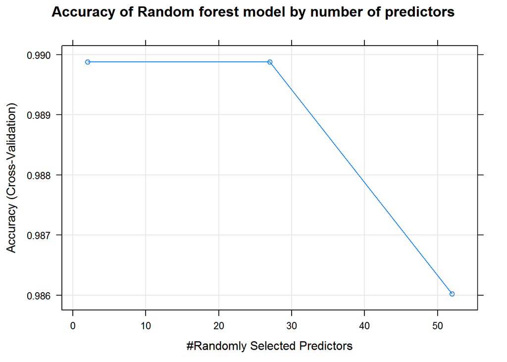

```r
plot(mdl_rf, main="Accuracy of Random forest model by number of predictors");
```

### 2. Decision Tree Visualization

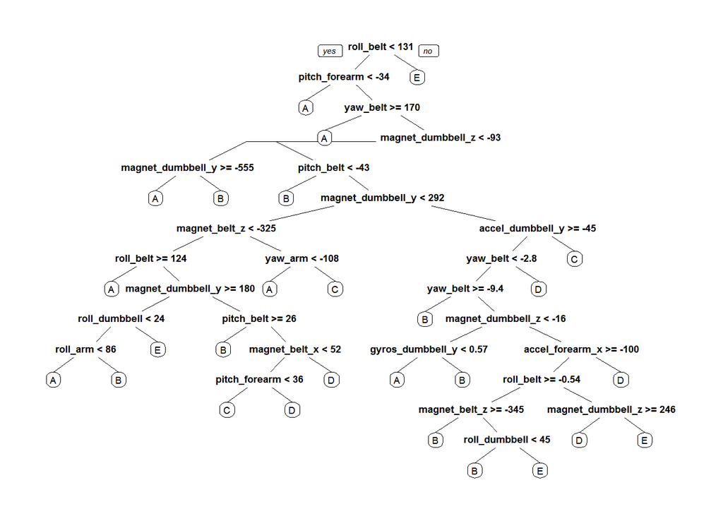

```r
tree_mdl = rpart(classe ~ ., data=train_partition, method="class");
prp(tree_mdl);
```